# HW2-EDA with R - Part1: Plotting

gGrosse jArndt

## Step 4 - Complete the following R tasks and answer questions

Now you’ll need to complete the following tasks in R. Just like we did in class, you should use a combination of markdown text (be concise, no need to write tons of text) to explain what you are doing and R code chunks to actually do it. When you are done, use the “Knit” button to generate an HTML file from your R Markdown.

Note that if you have errors in your R code, **knitr** will stop at the error and won’t create an html file. Sooo, you should comment out R code that has errors and write a little comment stating that it’s an error. Keep doing this until you successfully knit an html file based on your R Markdown document. You’ll be submitting both the html file as well as the Rmd file.

You’ll be submitting BOTH the completed R Markdown file as well as the generated HTML file. You’ll notice that I’ve left some empty code chunks as well as some partially filled in code chunks. Of course, feel free to add more code chunks as needed.

Let’s load a few libraries we’ll need:

```r
library(ggplot2)
```

### Problem 1 - Get the data into a dataframe

You should read the **county.csv** file into a data frame named county_df and **county_mi_df.csv** into a data frame named county_mi_df.

```r
county_df <- read.csv("data/county.csv")
county_mi_df <- read.csv("data/county_MI.csv")
```

- What does each row represent?

> Each row represents either a state’s county or Michigan’s counties.

Check the structure of each data.frame and use the `summary` function to begin exploring the data.

- Are there any NA values?
- What differences do you notice between the structure of the two data frames.

```r
str(county_df)
```

```
## 'data.frame':    3142 obs. of  40 variables:
##  $ State           : Factor w/ 51 levels "Alabama","Alaska",..: 1 1 1 1 1 1 1 1 1 1 ...
##  $ CountyId        : int  1055 1133 1053 1001 1003 1005 1007 1009 1011 1013 ...
##  $ State.Code      : Factor w/ 51 levels "AK","AL","AR",..: 2 2 2 2 2 2 2 2 2 2 ...
##  $ Region          : Factor w/ 4 levels "Midwest","Northeast",..: 3 3 3 3 3 3 3 3 3 3 ...
##  $ Division        : Factor w/ 9 levels "East North Central",..: 2 2 2 2 2 2 2 2 2 2 ...
##  $ County          : Factor w/ 1877 levels "Abbeville","Acadia Parish",..: 562 1836 558 83 90 101 150 165 226 236 ...
##  $ TotalPop        : int  103132 23968 37621 55036 203360 26201 22580 57667 10478 20126 ...
##  $ Men             : int  49738 11850 19326 26899 99527 13976 12251 28490 5616 9416 ...
##  $ Women           : int  53394 12118 18295 28137 103833 12225 10329 29177 4862 10710 ...
##  $ Hispanic        : num  3.7 3 2.2 2.7 4.4 4.2 2.4 9 0.3 0.3 ...
##  $ White           : num  78.3 94.1 60.2 75.4 83.1 45.7 74.6 87.4 21.6 52.2 ...
##  $ Black           : num  15.4 0.5 32.2 18.9 9.5 47.8 22 1.5 75.6 44.7 ...
##  $ Native          : num  0.5 0.3 3.6 0.3 0.8 0.2 0.4 0.3 1 0.1 ...
##  $ Asian           : num  0.7 0.3 0.4 0.9 0.7 0.6 0 0.1 0.7 1.1 ...
```

[output cut: 26 more lines]

```r
str(county_mi_df)
```

```
## 'data.frame':    83 obs. of  41 variables:
##  $ County          : Factor w/ 83 levels "Alcona","Alger",..: 1 2 3 4 5 6 7 8 9 10 ...
##  $ peninsula       : Factor w/ 2 levels "LP","UP": 1 2 1 1 1 1 2 1 1 1 ...
##  $ State           : Factor w/ 1 level "Michigan": 1 1 1 1 1 1 1 1 1 1 ...
##  $ CountyId        : int  26001 26003 26005 26007 26009 26011 26013 26015 26017 26019 ...
##  $ State.Code      : Factor w/ 1 level "MI": 1 1 1 1 1 1 1 1 1 1 ...
##  $ Region          : Factor w/ 1 level "Midwest": 1 1 1 1 1 1 1 1 1 1 ...
##  $ Division        : Factor w/ 1 level "East North Central": 1 1 1 1 1 1 1 1 1 1 ...
##  $ TotalPop        : int  10413 9254 114145 28730 23133 15238 8580 59607 105350 17462 ...
##  $ Men             : int  5247 5088 56997 14169 11479 7714 5112 29958 51875 8694 ...
##  $ Women           : int  5166 4166 57148 14561 11654 7524 3468 29649 53475 8768 ...
##  $ Hispanic        : num  1.4 1.4 7.2 1.3 2.1 2 1.5 2.7 5.2 2.4 ...
##  $ White           : num  96 84.2 88.7 96 95 94.9 73.1 94.6 90.4 93.9 ...
##  $ Black           : num  0.3 7.2 1.3 0.5 0.3 0.5 15.8 0.4 1.5 0.3 ...
##  $ Native          : num  0.5 3.3 0.5 0.4 0.8 1.3 4.7 0.2 0.2 1.4 ...
```

[output cut: 27 more lines]

```r
summary(county_df)
```

```
##       State         CountyId       State.Code         Region
##  Texas   : 254   Min.   : 1001   TX     : 254   Midwest  :1055
##  Georgia : 159   1st Qu.:18178   GA     : 159   Northeast: 217
##  Virginia: 133   Median :29176   VA     : 133   South    :1422
##  Kentucky: 120   Mean   :30384   KY     : 120   West     : 448
##  Missouri: 115   3rd Qu.:45080   MO     : 115
##  Kansas  : 105   Max.   :56045   KS     : 105
##  (Other) :2256                   (Other):2256
##                Division          County        TotalPop
##  West North Central:618   Washington:  30   Min.   :      74
##  South Atlantic    :588   Jefferson :  25   1st Qu.:   10945
##  West South Central:470   Franklin  :  24   Median :   25692
##  East North Central:437   Jackson   :  23   Mean   :  102166
##  East South Central:364   Lincoln   :  23   3rd Qu.:   67445
##  Mountain          :281   Madison   :  19   Max.   :10105722
##  (Other)           :384   (Other)   :2998
##       Men              Women            Hispanic          White
##  Min.   :     39   Min.   :     35   Min.   : 0.000   Min.   :  0.60
##  1st Qu.:   5514   1st Qu.:   5460   1st Qu.: 2.100   1st Qu.: 65.10
##  Median :  12798   Median :  12885   Median : 4.000   Median : 84.20
##  Mean   :  50292   Mean   :  51873   Mean   : 9.122   Mean   : 76.76
##  3rd Qu.:  33481   3rd Qu.:  34108   3rd Qu.: 9.300   3rd Qu.: 92.90
##  Max.   :4979641   Max.   :5126081   Max.   :99.200   Max.   :100.00
##
##      Black            Native           Asian          Pacific
##  Min.   : 0.000   Min.   : 0.000   Min.   : 0.00   Min.   : 0.00000
##  1st Qu.: 0.600   1st Qu.: 0.100   1st Qu.: 0.30   1st Qu.: 0.00000
##  Median : 2.100   Median : 0.300   Median : 0.60   Median : 0.00000
##  Mean   : 8.896   Mean   : 1.812   Mean   : 1.32   Mean   : 0.08546
##  3rd Qu.: 9.875   3rd Qu.: 0.600   3rd Qu.: 1.20   3rd Qu.: 0.10000
##  Max.   :86.900   Max.   :90.300   Max.   :41.80   Max.   :33.70000
##
##  VotingAgeCitizen      Income         IncomeErr      IncomePerCap
##  Min.   :     59   Min.   : 19264   Min.   :  262   Min.   : 9334
##  1st Qu.:   8279   1st Qu.: 41123   1st Qu.: 1762   1st Qu.:21810
##  Median :  19480   Median : 48066   Median : 2619   Median :25272
##  Mean   :  72223   Mean   : 49754   Mean   : 3176   Mean   :26040
##  3rd Qu.:  51224   3rd Qu.: 55764   3rd Qu.: 3834   3rd Qu.:29126
##  Max.   :6218279   Max.   :129588   Max.   :41001   Max.   :69529
##
```

[output cut: 33 more lines]

```
##  Min.   :31.10   Min.   : 4.40   Min.   : 0.000   Min.   :0.0000
##  1st Qu.:71.70   1st Qu.:12.70   1st Qu.: 5.200   1st Qu.:0.1000
##  Median :76.30   Median :15.70   Median : 6.800   Median :0.2000
##  Mean   :75.07   Mean   :16.89   Mean   : 7.758   Mean   :0.2824
##  3rd Qu.:80.30   3rd Qu.:19.50   3rd Qu.: 9.175   3rd Qu.:0.3000
##  Max.   :88.80   Max.   :64.80   Max.   :38.000   Max.   :8.0000
##
##   Unemployment
##  Min.   : 0.000
##  1st Qu.: 4.400
##  Median : 6.100
##  Mean   : 6.364
##  3rd Qu.: 7.800
##  Max.   :28.800
##
```

```r
summary(county_mi_df)
```

```
##      County   peninsula      State       CountyId     State.Code
##  Alcona : 1   LP:68     Michigan:83   Min.   :26001   MI:83
##  Alger  : 1   UP:15                   1st Qu.:26042
##  Allegan: 1                           Median :26083
##  Alpena : 1                           Mean   :26083
##  Antrim : 1                           3rd Qu.:26124
##  Arenac : 1                           Max.   :26165
##  (Other):77
##      Region                 Division     TotalPop            Men
##  Midwest:83   East North Central:83   Min.   :   2136   Min.   :  1099
##                                       1st Qu.:  22348   1st Qu.: 11080
##                                       Median :  38023   Median : 20592
##                                       Mean   : 119585   Mean   : 58802
##                                       3rd Qu.:  94904   3rd Qu.: 47394
##                                       Max.   :1763822   Max.   :848339
##
##      Women           Hispanic         White           Black
##  Min.   :  1037   Min.   : 0.70   Min.   :49.70   Min.   : 0.200
##  1st Qu.: 11190   1st Qu.: 1.65   1st Qu.:84.55   1st Qu.: 0.500
##  Median : 18311   Median : 2.60   Median :91.50   Median : 1.300
##  Mean   : 60783   Mean   : 3.46   Mean   :88.10   Mean   : 3.875
##  3rd Qu.: 47509   3rd Qu.: 4.50   3rd Qu.:94.70   3rd Qu.: 4.750
##  Max.   :915483   Max.   :14.50   Max.   :97.50   Max.   :38.900
##
##      Native           Asian           Pacific        VotingAgeCitizen
##  Min.   : 0.100   Min.   :0.0000   Min.   :0.00000   Min.   :   1770
##  1st Qu.: 0.300   1st Qu.:0.4000   1st Qu.:0.00000   1st Qu.:  17666
##  Median : 0.500   Median :0.5000   Median :0.00000   Median :  30374
##  Mean   : 1.263   Mean   :0.9976   Mean   :0.01687   Mean   :  89582
##  3rd Qu.: 0.950   3rd Qu.:0.7500   3rd Qu.:0.00000   3rd Qu.:  73744
##  Max.   :16.900   Max.   :8.7000   Max.   :0.10000   Max.   :1279502
##
##      Income        IncomeErr     IncomePerCap   IncomePerCapErr
##  Min.   :32309   Min.   : 405   Min.   :18199   Min.   : 170.0
##  1st Qu.:42464   1st Qu.:1314   1st Qu.:22668   1st Qu.: 616.0
##  Median :45231   Median :1559   Median :24859   Median : 796.0
##  Mean   :47531   Mean   :1700   Mean   :25596   Mean   : 893.9
##  3rd Qu.:51407   3rd Qu.:1974   3rd Qu.:27286   3rd Qu.:1093.5
##  Max.   :78430   Max.   :5475   Max.   :40941   Max.   :2559.0
##
```

[output cut: 25 more lines]

```
##  Min.   :2.300   Min.   :13.60   Min.   :   856   Min.   :65.80
##  1st Qu.:3.500   1st Qu.:20.50   1st Qu.:  8318   1st Qu.:77.95
##  Median :4.200   Median :22.30   Median : 15821   Median :81.20
##  Mean   :4.408   Mean   :23.11   Mean   : 54517   Mean   :80.48
##  3rd Qu.:5.150   3rd Qu.:26.10   3rd Qu.: 44872   3rd Qu.:83.15
##  Max.   :8.900   Max.   :34.70   Max.   :722115   Max.   :87.90
##
##    PublicWork     SelfEmployed      FamilyWork      Unemployment
##  Min.   : 7.20   Min.   : 3.200   Min.   :0.0000   Min.   : 3.60
##  1st Qu.:10.15   1st Qu.: 5.200   1st Qu.:0.1000   1st Qu.: 6.10
##  Median :11.50   Median : 6.300   Median :0.2000   Median : 7.20
##  Mean   :12.80   Mean   : 6.465   Mean   :0.2687   Mean   : 7.62
##  3rd Qu.:14.35   3rd Qu.: 7.500   3rd Qu.:0.3500   3rd Qu.: 8.70
##  Max.   :28.20   Max.   :11.400   Max.   :1.0000   Max.   :13.90
##
```

> The differences between the two data frames is that the county_mi_df has more colums than the other. The reason being is that we are looking at a specfic state structure rather that multiple states at once. From the structures and the summaries there do seem to be some NAs that are implicit.

**Unless otherwise specified, you should use the ggplot2 package for all of the following plots.**

### Problem 2 - Basic plots for Income

Create a histogram and a kernel density plot for Income and for IncomePerCap for the entire US (i.e. use the `county_df` dataframe.) The Income field is median income for the county and IncomePerCap is aggregate income divided by population size, for the county.

In addition, compute and display the following statistics for Income and IncomePerCap:

- mean and median
- standard deviation
- min, max and range
- 95th and 99th percentile
- IQR
- coefficient of variation

```r
##Values
meanIncome <- mean(county_df$Income)
medianIncome <- median(county_df$Income)
standIncome <- sd(county_df$Income)
minIncome <- min(county_df$Income)
maxIncome <- max(county_df$Income)
rangeIncome <- range(county_df$Income)
percentilesIncome <- quantile(county_df$Income, probs = c(.95, .99))
IQRIncome <- IQR(county_df$Income)
cvIncome <- standIncome / meanIncome * 100

##output
meanIncome
```

```
## [1] 49754.16
```

```r
medianIncome
```

```
## [1] 48065.5
```

```r
standIncome
```

```
## [1] 13154.42
```

```r
minIncome
```

```
## [1] 19264
```

```r
maxIncome
```

```
## [1] 129588
```

```r
rangeIncome
```

```
## [1]  19264 129588
```

```r
percentilesIncome
```

```
##      95%      99%
## 74886.90 93220.62
```

```r
IQRIncome
```

```
## [1] 14640.5
```

```r
cvIncome
```

```
## [1] 26.43884
```

```r
##Values

meanIncomePerCap <- mean(county_df$IncomePerCap)
medianIncomePerCap <- median(county_df$IncomePerCap)
standIncomePerCap <- sd(county_df$IncomePerCap)
minIncomePerCap <- min(county_df$IncomePerCap)
maxIncomePerCap <- max(county_df$IncomePerCap)
rangeIncomePerCap <- range(county_df$IncomePerCap)
percentilesIncomePerCap <- quantile(county_df$IncomePerCap, probs = c(.95, .99))
IQRIncomePerCap <- IQR(county_df$IncomePerCap)
cvIncomePerCap <- standIncomePerCap / meanIncomePerCap * 100

##output
meanIncomePerCap
```

```
## [1] 26039.64
```

```r
medianIncomePerCap
```

```
## [1] 25272.5
```

```r
standIncomePerCap
```

```
## [1] 6270.035
```

```r
minIncomePerCap
```

```
## [1] 9334
```

```r
maxIncomePerCap
```

```
## [1] 69529
```

```r
rangeIncomePerCap
```

```
## [1]  9334 69529
```

```r
percentilesIncomePerCap
```

```
##      95%      99%
## 37312.75 46555.08
```

```r
IQRIncomePerCap
```

```
## [1] 7316
```

```r
cvIncomePerCap
```

```
## [1] 24.07881
```

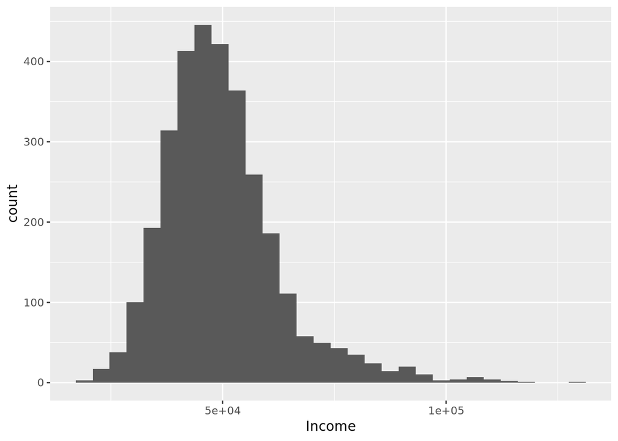

```r
plot <- ggplot(county_df) + geom_histogram(aes(x = Income))
plot_2 <- ggplot(county_df) + geom_histogram(aes(x = IncomePerCap))

plot_density1 <- ggplot(county_df) + geom_density(aes(x = Income), fill="grey50")
plot_density2 <- ggplot(county_df) + geom_density(aes(x = IncomePerCap), fill="grey50")


plot
```

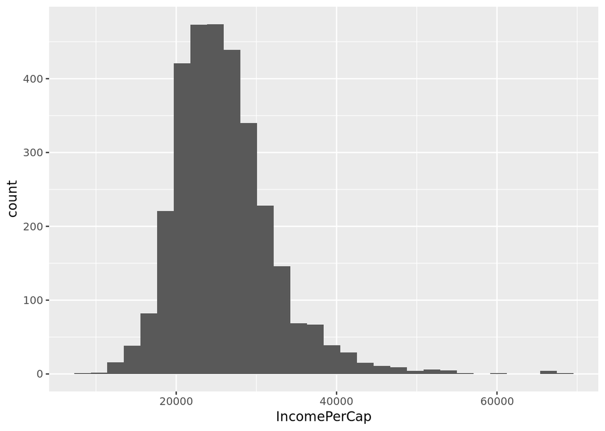

```r
plot_2
```

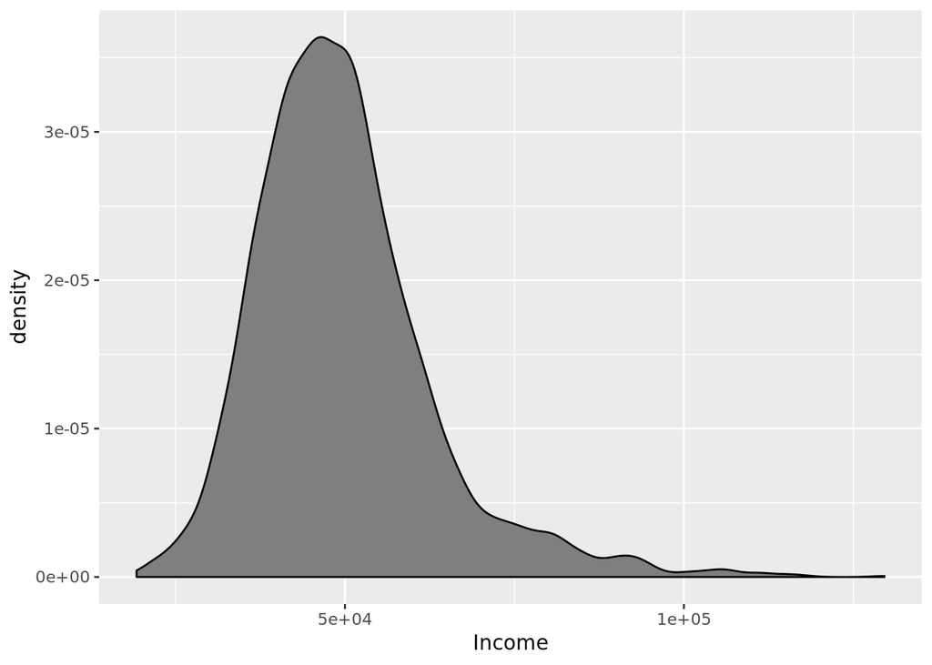

```r
plot_density1
```

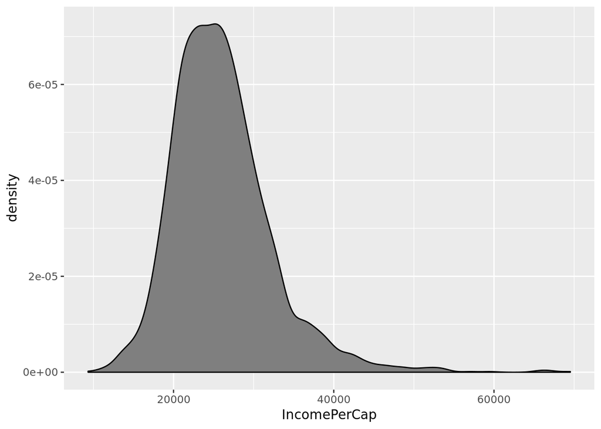

```r
plot_density2
```

Write a short paragraph describing the distribution of of these two variables.

Repeat the histogram for Income but make the following style changes to the plot.

- Add a title such as “Distribution of median income for US counties”
- Change y-axis label to “Number of counties”
- Change x-axis label to “Median income”
- Change the colors of the bars to something other than the default

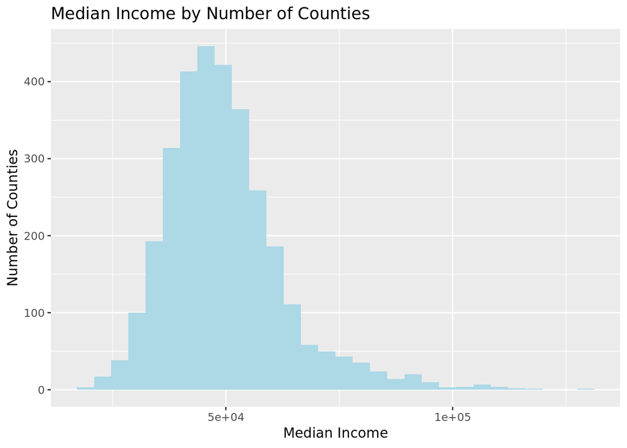

```r
newHisto <- ggplot(county_df) + geom_histogram(aes(x = Income), fill="lightblue")
print(newHisto + labs(y="Number of Counties", x="Median Income") + ggtitle("Median Income by Number of Counties"))
```

Now create a set of histograms for Income in which you facet by Division.

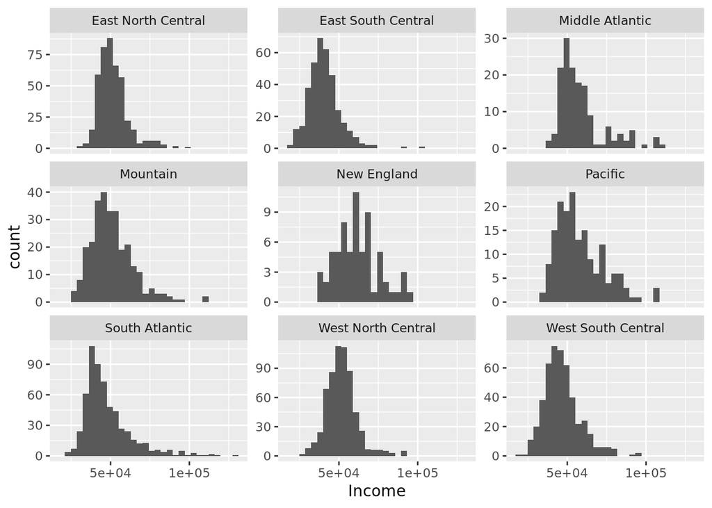

```r
ggplot(county_df) +
  geom_histogram(aes(x=Income)) +
  facet_wrap(~ Division, scale="free_y")
```

Since the number of counties varies by Division, create a new version of the plot above but modify so that the y-axis shows frequency percentages instead of counts. Hint: `..density..`

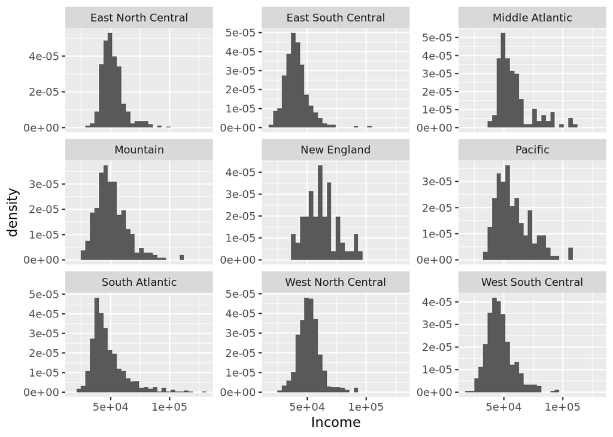

```r
ggplot(county_df) +
  geom_histogram(aes(x=Income, y=..density..)) +
  facet_wrap(~ Division, scale = "free_y")
```

Now create boxplots and violin plots for the same two variables. However, you’ll see that for both of these plot types, ggplot wants an `x` aesthetic to act as a grouping variable. Use the `region` field as your `x` aesthetic. Note anything of interest revealed by these plots.

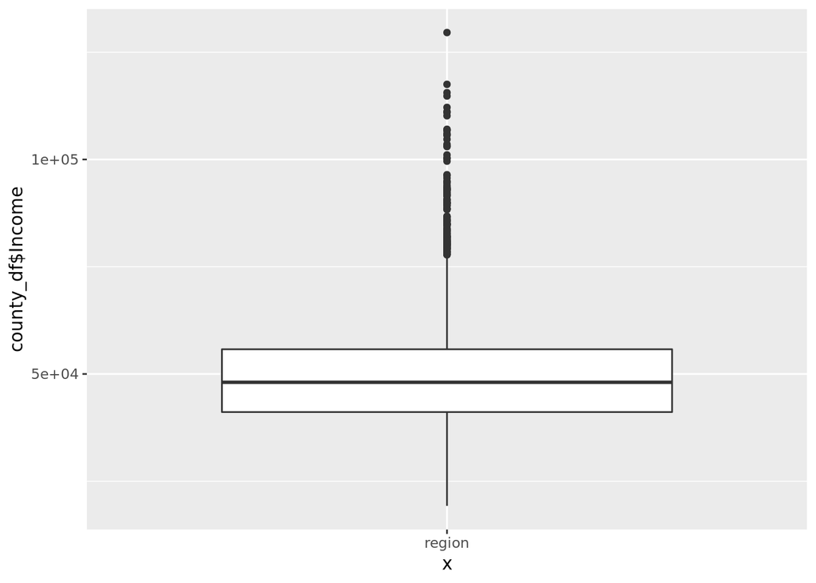

```r
# Boxplots and violin plots
gBoxPlot1 <- ggplot(county_df, aes(x='region', y=county_df$Income))
gBoxPlot2 <- ggplot(county_df, aes(x='region', y=county_df$IncomePerCap))

gViolinPlot1 <- ggplot(county_df, aes(x='region', y=county_df$Income))
gViolinPlot2 <- ggplot(county_df, aes(x='region', y=county_df$IncomePerCap))

gBoxPlot1 + geom_boxplot()
```

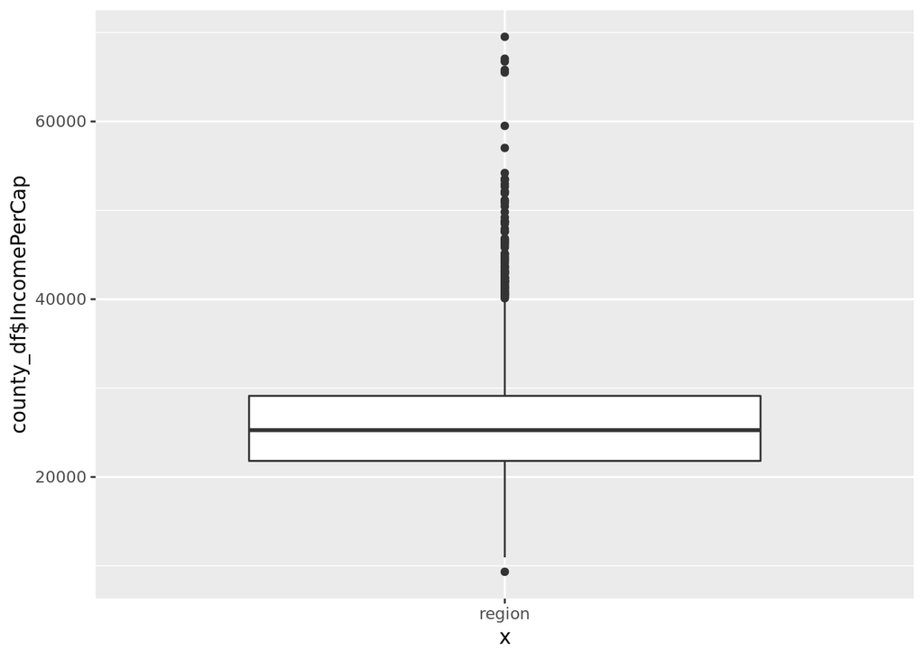

```r
gBoxPlot2 + geom_boxplot()
```

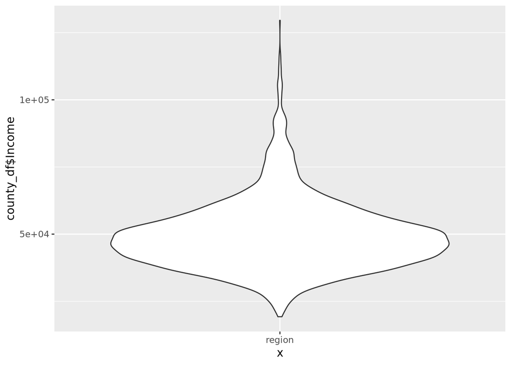

```r
gViolinPlot1 + geom_violin()
```

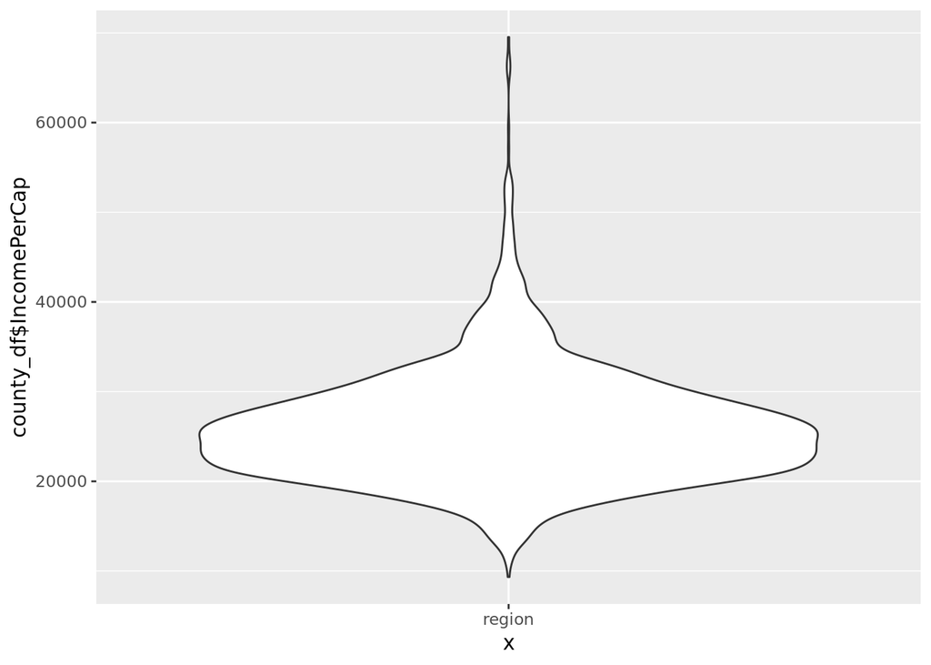

```r
gViolinPlot2 + geom_violin()
```

Repeat the histogram of Income but only for counties with less than 500,000 people. Do NOT use dplyr to do the filtering - instead, use boolean indexing (see intro to dataframes Rmd file).

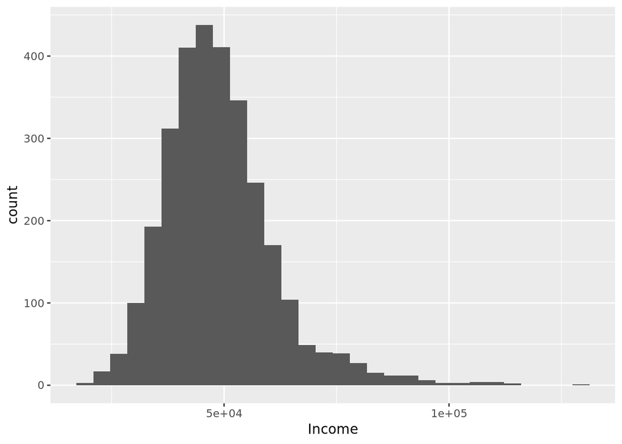

```r
index <- county_df[county_df$TotalPop < 500000,]
plot <- ggplot(index) + geom_histogram(aes(x = Income))
plot
```

**Hacker Extra** - Also create a kernel density plot of Income overlaid on a histogram of Income.

### Problem 3 - How do Michigan’s peninsulas compare?

Create violin plots showing Income by peninsula. Make sure your graph has a title and good axis labels.

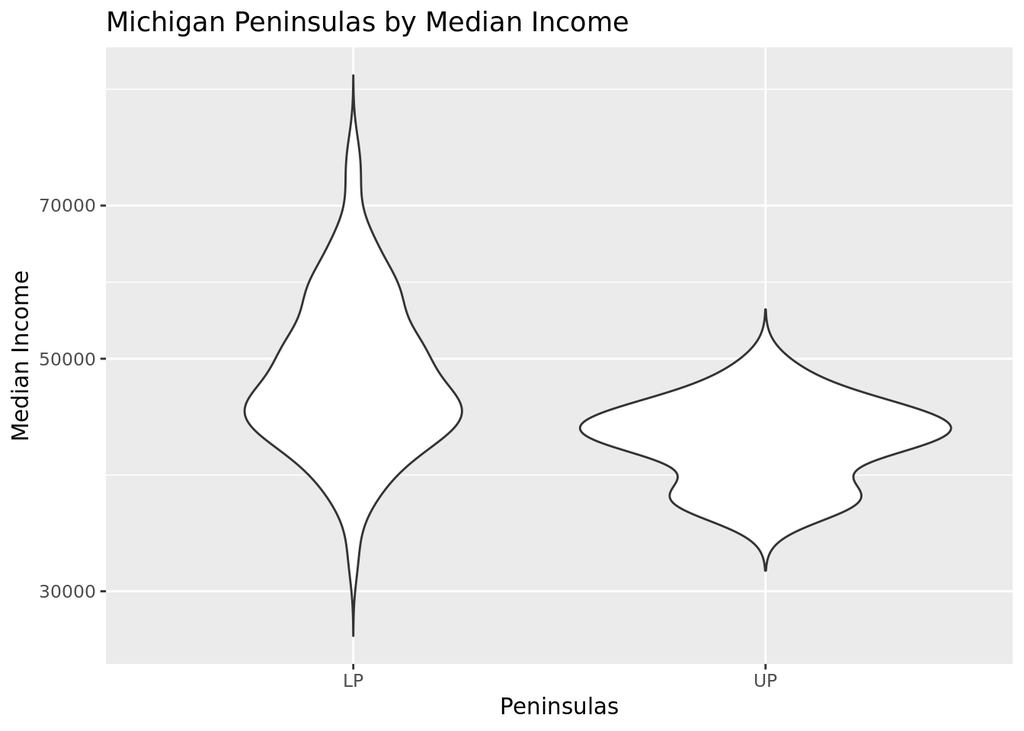

```r
michiganViolin <- ggplot(county_mi_df) + geom_violin(aes(x=peninsula, y=Income), trim = FALSE) + scale_y_log10()
print(michiganViolin + labs(y="Median Income", x="Peninsulas") + ggtitle("Michigan Peninsulas by Median Income"))
```

Do the peninsulas differ with respect to distribution of median income over the counties?

> Yes they do differ with respect to distribution becasue the Lower Peninsula has more population than that of the Upper peninsula so the median income with respect to the two peninsulas.

Create several boxplots and/or violin plots showing how the peninsulas compare with respect to some of the other variables. Summarize your findings in a few short paragraphs.

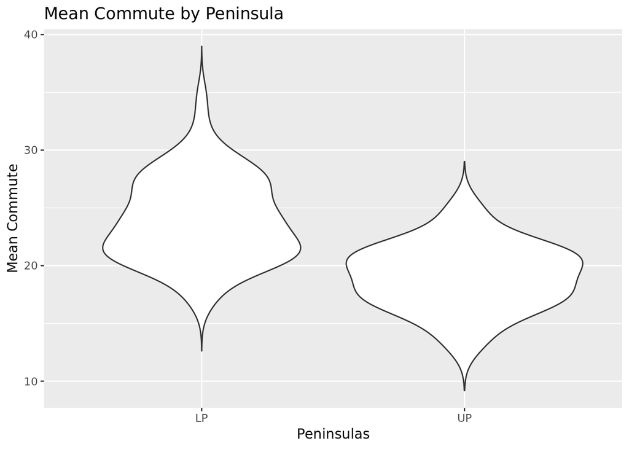

```r
#MeanCommute vs peninsula
penCommute <- ggplot(county_mi_df) + geom_violin(aes(x = peninsula, y = MeanCommute), trim = FALSE)
print(penCommute + labs(y="Mean Commute", x="Peninsulas") + ggtitle("Mean Commute by Peninsula"))
```

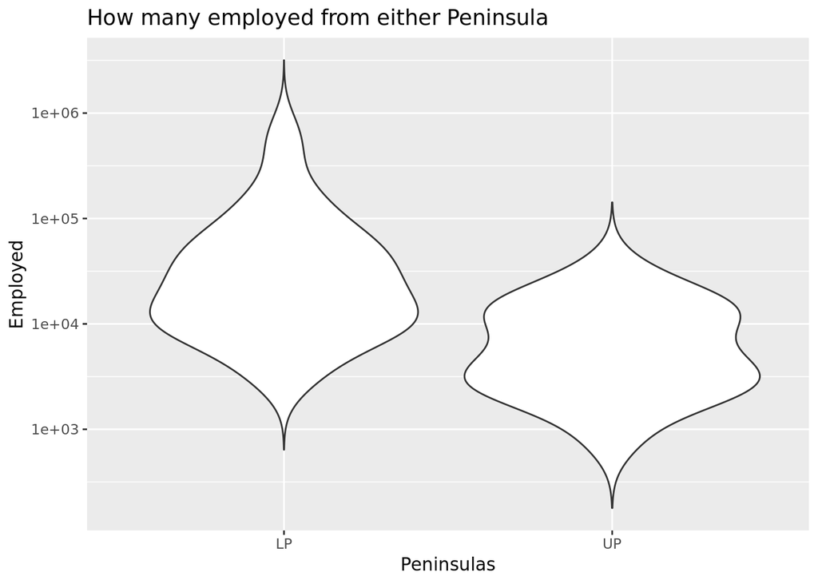

```r
#Employed vs peninsula
penEmployed <- ggplot(county_mi_df) + geom_violin(aes(x = peninsula, y = Employed), trim = FALSE) + scale_y_log10()
print(penEmployed + labs(y="Employed", x="Peninsulas") + ggtitle("How many employed from either Peninsula"))
```

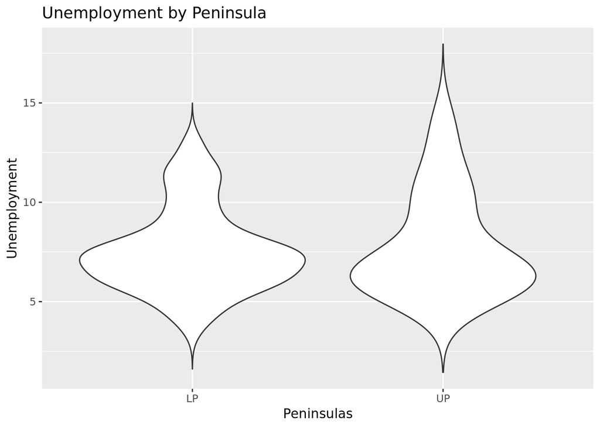

```r
#Unemployment vs peninsula
penUnemployment <- ggplot(county_mi_df) + geom_violin(aes(x = peninsula, y = Unemployment), trim = FALSE)
print(penUnemployment + labs(y="Unemployment", x="Peninsulas") + ggtitle("Unemployment by Peninsula"))
```

```r
# rm(penProduction)
```

### Problem 4 - Basic bar chart

Create a bar chart showing the number of counties by State in the US. Make sure your graph has a title and good axis labels. Figure out how to format the x-axis labels so that they don’t obscure each other.

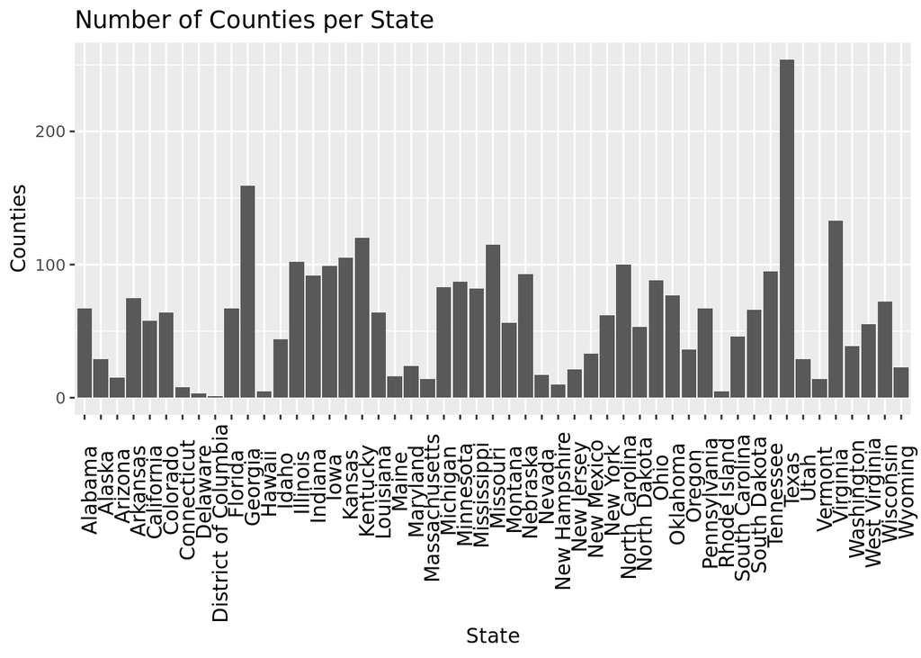

```r
countiesState <- ggplot(county_df, y = County) + geom_bar(aes(x = State))
countiesState <- countiesState + theme(axis.text.x = element_text(color="black", size=11, angle=90, vjust = .8, hjust = 0.8))
countiesState <- countiesState + labs(y="Counties", x="State") + ggtitle("Number of Counties per State")

countiesState
```

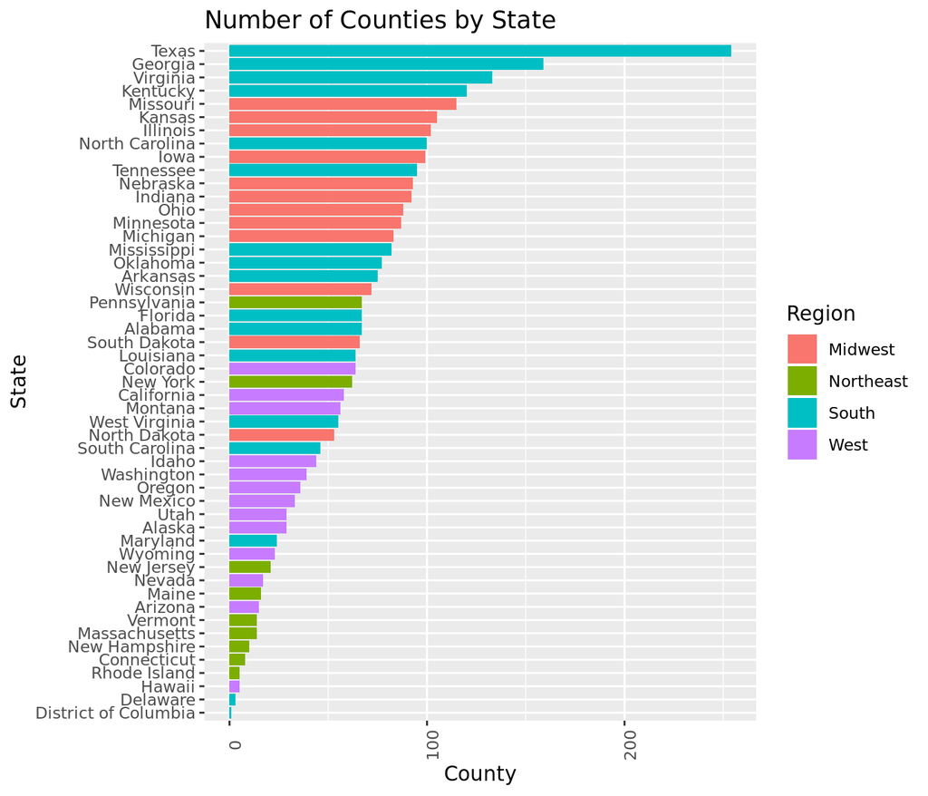

```r
countiesState <- ggplot(county_df, aes( x = reorder(State, State, function(x) + length(x)), fill = Region)) + geom_bar() + theme(axis.text.x =element_text(angle = 90)) +  coord_flip()
print(countiesState + labs(y ='County', x='State') + ggtitle('Number of Counties by State'))
```

### Problem 5 - Basic scatter plots

Create a scatter plot using the Michigan only data frame comparing IncomePerCap and MeanCommute.

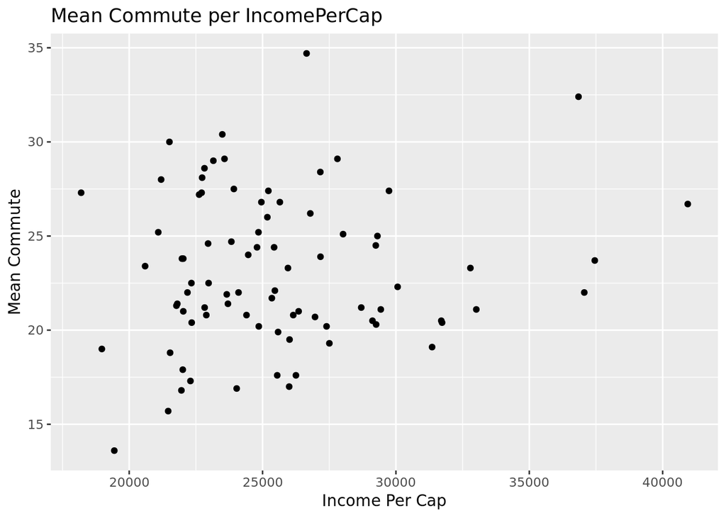

```r
meanCommuteIncomePerCap <- ggplot(county_mi_df, aes(x = IncomePerCap, y = MeanCommute)) + geom_point()
meanCommuteIncomePerCap + labs(y="Mean Commute", x="Income Per Cap") + ggtitle("Mean Commute per IncomePerCap")
```

Create a modified version of the above scatter plot in which the point color is mapped to peninsula and the size is mapped to total population. In addition, create a similar plot comparing Income and Professional.

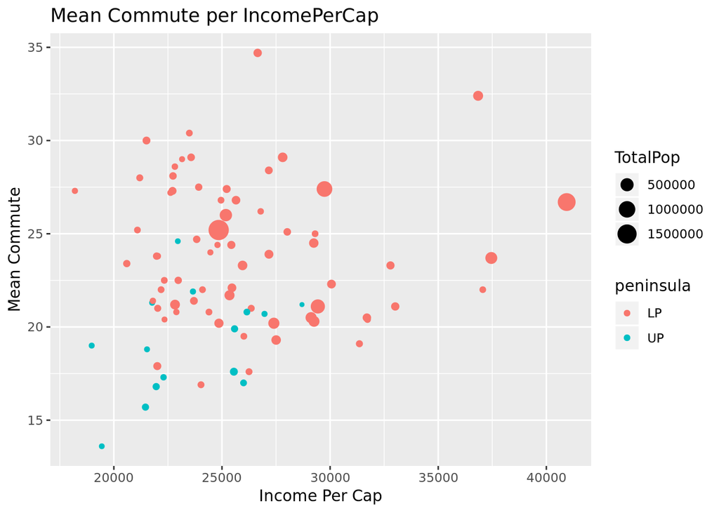

```r
# Scatter Pot for Income Per Cap and Mean Commute
meanplot2 <- ggplot(county_mi_df, aes(x=IncomePerCap, y=MeanCommute)) + geom_point(aes(color = peninsula, size=TotalPop))
meanplot2 + labs(y="Mean Commute", x="Income Per Cap") + ggtitle("Mean Commute per IncomePerCap")
```

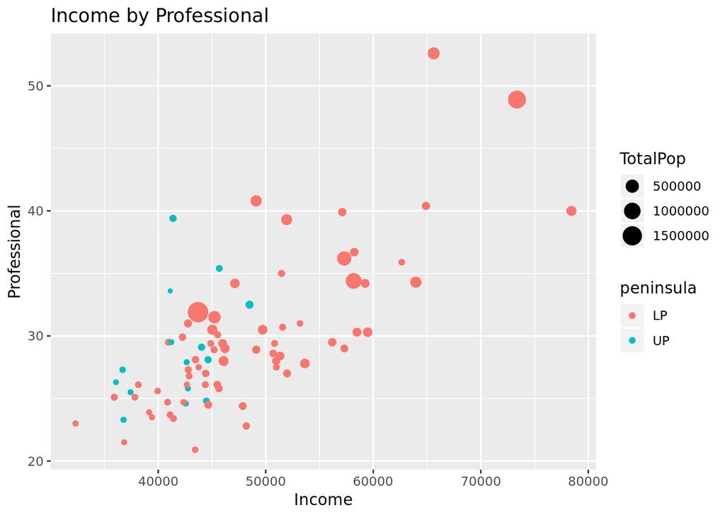

```r
# Scatter Plot for Income and Professional
incomeProfessional <- ggplot(county_mi_df, aes(x=Income, y=Professional)) + geom_point(aes(color = peninsula, size=TotalPop))
incomeProfessional + labs(y="Professional", x="Income") + ggtitle("Income by Professional")
```

> Your thoughts on the relationship between these variables? Looking at the plot there doesn’t seem to be any correlation between Mean Commute and IncomePerCap. On the other hand, Professional and Income seem to have a positive correlation, with most of the professional data points being in the lower peninsula.

Now, create a few more scatter plots using variables of your choosing in which you facet by peninsula as well. How do the relationships compare across the peninsulas?

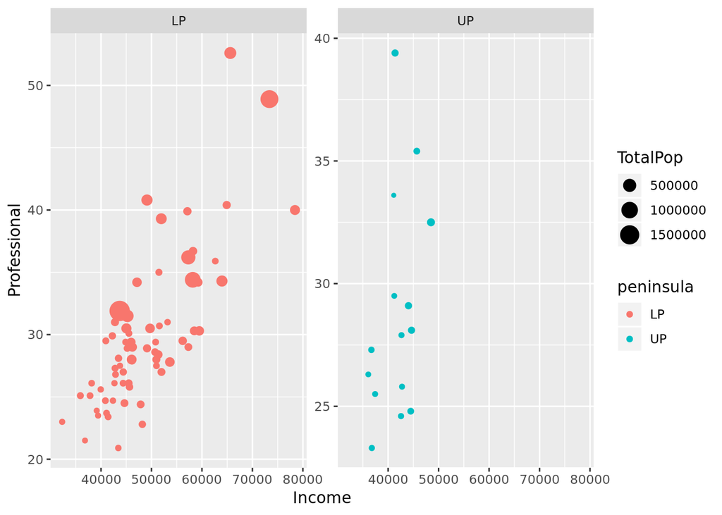

```r
## Scatter PLot of Income and Professional
scatterIncome <- ggplot(county_mi_df, aes(x=Income, y=Professional)) +
  geom_point(aes(color = peninsula, size=TotalPop)) +
  facet_wrap(~ peninsula, scale="free_y")
scatterIncome
```

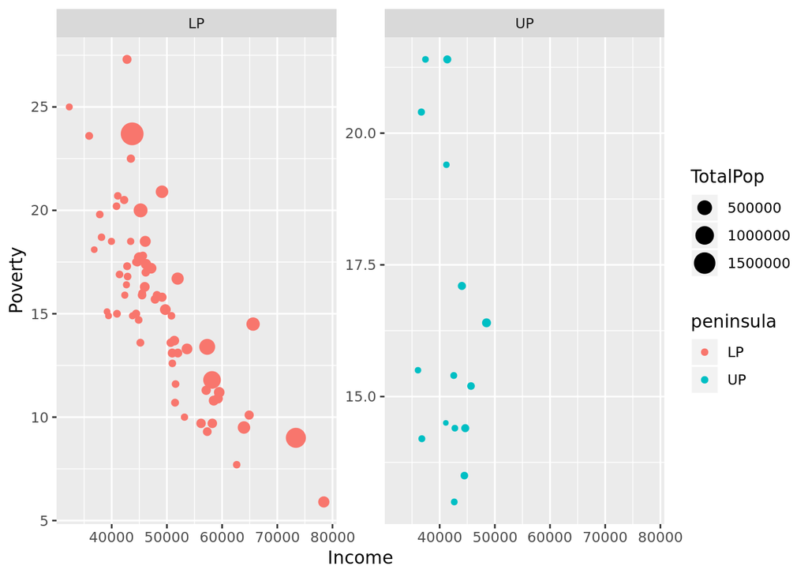

```r
## Scatter Plot of Income and Poverty
scatterPoverty <- ggplot(county_mi_df, aes(x=Income, y=Poverty)) +
  geom_point(aes(color = peninsula, size=TotalPop))  +
  facet_wrap(~ peninsula, scale="free_y")
  scatterPoverty
```

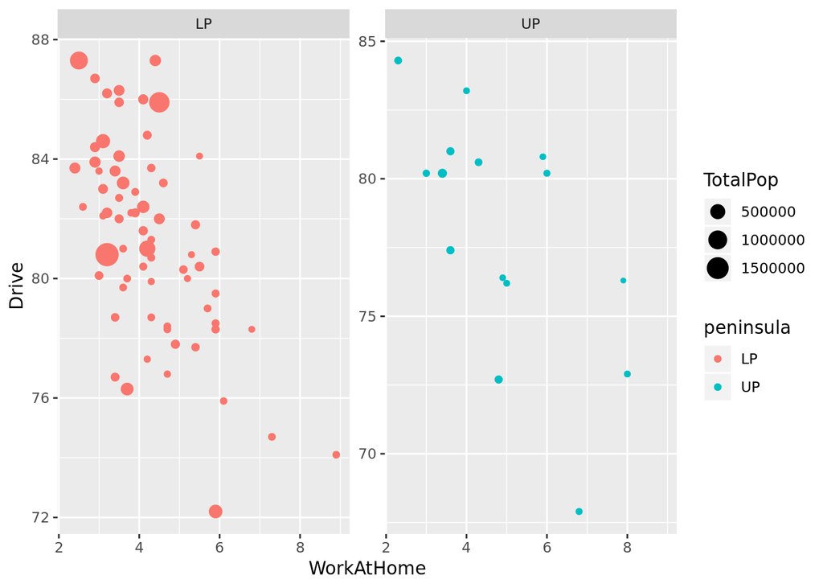

```r
##Scatter plot of people who work at home and drive
scatterWalk <- ggplot(county_mi_df, aes(x = WorkAtHome, y = Drive)) +
  geom_point(aes(color = peninsula, size=TotalPop))  +
  facet_wrap(~ peninsula, scale="free_y")
  scatterWalk
```

Now use the full US data frame, county_df.

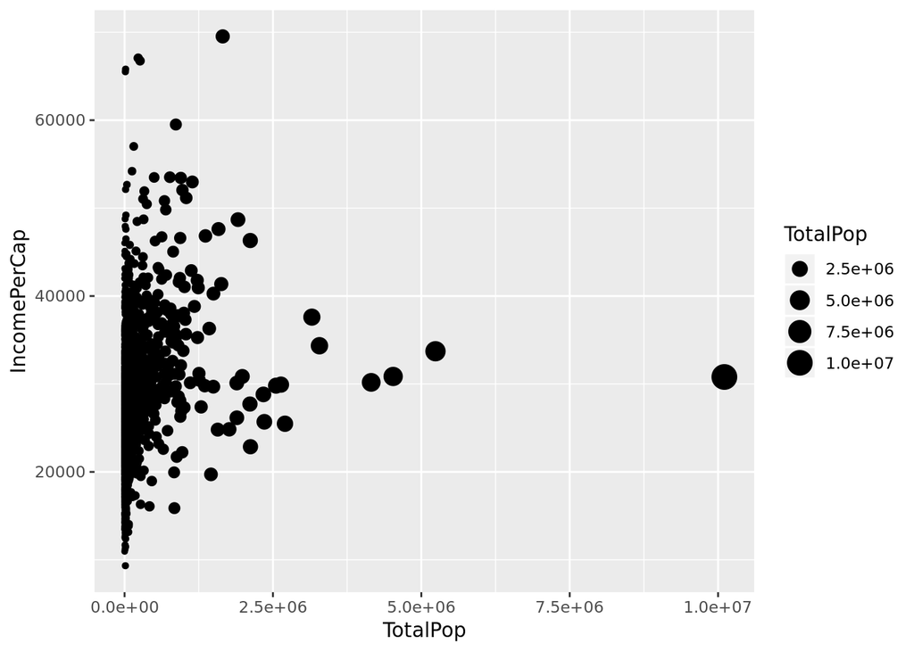

```r
scatterTotalPop <- ggplot(county_df, aes(x=TotalPop, y=IncomePerCap)) +
  geom_point(aes(size=TotalPop))
scatterTotalPop
```

The widely varying values make this difficult to interpret in terms of looking for patterns. So, figure out a way to either change the axis scales or the plotted data itself to use a base 10 logarithmic scale (or transform). Write a short paragraph on why one might want to use a log scale or log transform of data when plotting.

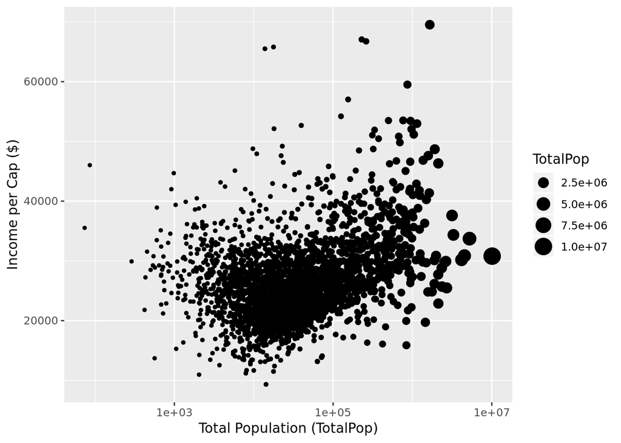

```r
scatterTotalPop <- ggplot(county_df, aes(x=TotalPop, y=IncomePerCap)) +
  geom_point(aes(size=TotalPop)) + scale_x_log10()
scatterTotalPop + xlab("Total Population (TotalPop)") + ylab("Income per Cap ($)")
```

```r
# scatterTotalPop <- ggplot(county_df, aes(x=TotalPop, y=IncomePerCap)) +
#   geom_point(aes(size=TotalPop)) + log10(x)
# scatterTotalPop
```

> The data wouldn’t be scale without the log scale. Due this the graph would look like something like in the last code chunk and therefore a log is needed. The numbers in that last chunk are high for a small variable and because of this again a log must be used to scale down the data and make the graph readable.